[figure not shown]

# Informe Técnico - Caso Monopoly

Integrantes:

- Diego Gieminiani G.
- Esteban Díaz C.
- Marian Moreno O.

Docente: Cristian Álvarez

Sección: MLY0100 - 005V

# Caso Machine Learning

## Evaluación 1

### CONTEXTO CASO

En el presente caso, nos han contactado como equipo de análisis de datos y modelado de Machine Learning para analizar y realizar modelos predictivos al conocido Banco "Monopoly".

Esta institución financiera se enfrenta al desafío de comprender y predecir el comportamiento de sus clientes. Para abordar este desafío, la institución ha recopilado una amplia gama de datos sobre sus clientes y sus transacciones con tarjeta de crédito, débito, cuentas corrientes, créditos hipotecarios, entre otra gran variedad de datos que poseen de los clientes. Estos datos incluyen información demográfica, financiera y de comportamiento de los clientes en base a sys actividades y transacciones, así como detalles sobre las pagos realizados con sus tarjetas en un determinado tiempo.

El objetivo de este caso es utilizar estos datos para desarrollar modelos predictivos que ayuden a la institución financiera a tomar decisiones informadas y por sobre todas las cosas fundamentadas sobre cómo actuar e interactuar con sus clientes y también gestionar su cartera de cuentas (tarjetas, montos, facturados, cupos de tarjetas, deudas, entre otras) de manera más efectiva y personalizada para ofrecer un mejor servicio.

| Variable | Descripción |
| --- | --- |
| Correlativo | Identificador cliente |
| Región | Región de Residencia |
| Renta | Renta del cliente |
| Sexo | Sexo |
| Subsegmento | Subsegmento |
| Edad | Edad |
| Adicional | Antigüedad del cliente (meses) |
| CambioPin | Indicador del cambio de clave secreta de la tarjeta |
| Consumo | Indicador de Crédito de Consumo |
| Debito | Indicador de Tenencia de TD |
| Ctacte | Indicador de Cuenta Corriente |
| Cuentas | Número de cuentas que tiene el cliente |
| Hipotecario | Indicador de Crédito Hipotecario |
| Internauta | Indicador de cliente Internauta que usa la web Monopoly |
| Monoproducto | Indicador de si el cliente es solo poseedor de una TC |
| TC | Número de TC que tiene el cliente |
| Dualidad | Indicador de Dualidad (Cliente es dual si tiene 2 o más TC) |
| CUPO_L1 | Cupo de la tarjeta de crédito para compras nacionales |
| CUPO_MX | Cupo de la tarjeta de crédito para compras internacionales |
| CUPO_L2 | Cupo de la tarjeta de crédito para avances en cuotas |
| Col_T12 | Colocación del cliente en TC en el mes X |
| ColL1TE_T12 | Revolving del cliente en TC en el mes X |
| EeccInt_T12 | Monto internacional exigido en el estado de cuenta del cliente en el mes X |
| EeccNac_T12 | Monto nacional exigido en el estado de cuenta del cliente en el mes X |
| Fac_T12 | Monto facturado por el cliente en TC en el mes X |
| FacAI_T12 | Monto facturado en avances internacionales por el cliente en TC en el mes X |
| FacAN_T12 | Monto facturado en avances nacionales por el cliente en TC en el mes X |
| FacCCOT_T12 | Monto facturado en compras en cuotas con tasa por el cliente en TC en el mes X |
| FacCCPC_T12 | Monto facturado en compras en cuotas precio contado por el cliente en TC en el mes X |
| FacCI_T12 | Monto facturado en compras internacionales por el cliente en TC en el mes X |
| FacCN_T12 | Monto facturado en compras nacionales por el cliente en TC en el mes X |
| FacCOL_T12 | Monto facturado en avances en cuotas por el cliente en TC en el mes X |
| FacDebAtm_T12 | Monto facturado en avances por el cliente en TD en el mes X |
| FacDebCom_T12 | Monto facturado en compras por el cliente en TD en el mes X |
| FacPAT_T12 | Monto facturado en PAT por el cliente en TC en el mes X |
| FlgAct_T12 | Indicador de actividad en el mes X en la TC |
| FlgActAI_T12 | Indicador de actividad en avances internacionales en el mes X en la TC |
| FlgActAN_T12 | Indicador de actividad en avances nacionales en el mes X in la TC |
| FlgActCCOT_T12 | Indicador de actividad en compras nacionales en cuotas con tasa en el mes X en la TC |
| FlgActCCPC_T12 | Indicador de actividad en compras nacionales en cuotas precio contado en el mes X en la TC |
| FlgActCI_T12 | Indicador de actividad en compras internacionales en el mes X en la TC |
| FlgActCN_T12 | Indicador de actividad en compras nacionales en el mes X en la TC |
| FlgActCOL_T12 | Indicador de actividad en avances en cuotas con tasa en el mes X en la TC |
| FlgActPAT_T12 | Indicador de actividad en PAT en el mes X en la TC |
| PagoInt_T12 | Monto de pagos de deuda internacional del cliente en el mes X |
| PagoNac_T12 | Monto de pagos de deuda nacional del cliente en el mes X |
| Txs_T12 | Número de transacciones realizadas por el cliente en TC en el mes X |
| TxsAI_T12 | Número de transacciones en avances internacionales realizadas por el cliente en TC en el mes X |
| TxsAN_T12 | Número de transacciones en avances nacionales realizadas por el cliente en TC en el mes X |
| TxsCCOT_T12 | Número de transacciones en compras en cuotas con tasa realizadas por el cliente en TC en el mes X |
| TxsCCPC_T12 | Número de transacciones en compras en cuotas precio contado realizadas por el cliente en TC en el mes X |
| TxsCI_T12 | Número de transacciones en compras internacionales realizadas por el cliente en TC en el mes X |
| TxsCN_T12 | Número de transacciones en compras nacionales realizadas por el cliente en TC en el mes X |
| TxsCOL_T12 | Número de transacciones en avances en cuotas realizadas por el cliente en TC en el mes X |
| TxsDebAtm_T12 | Número de transacciones en avances realizadas por el cliente en TD en el mes X |
| TxsDebCom_T12 | Número de transacciones en compras realizadas por el cliente en TD en el mes X |
| TxsPAT_T12 | Número de transacciones en PAT realizadas por el cliente en TC en el mes X |
| UsoL1_T12 | Monto de deuda en la línea de compras en la TC en el mes X |
| UsoL2_T12 | Monto de deuda en la línea de avances en cuotas en la TC en el mes X |
| UsoLI_T12 | Monto de deuda en la línea de compras internacionales en la TC en el mes X |

## Fase 1: Business Understanding

### Visión General de los datos

```python
# Importamos librerías

import pandas as pd
import numpy as np
import seaborn as sb
import matplotlib.pyplot as plt
```

```python
df = pd.read_csv('Base_clientes_Monopoly.csv', sep=';', low_memory=False)
```

Bajo el enfoque del modelo CRISP-DM, la comprensión del contexto del negocio se convierte en un elemento esencial tanto para el análisis de datos como para la identificación de los aspectos críticos dentro del ámbito de estudio en esta institución financiera.

En el contexto específico de la institución, se nos brinda una orientación general que abarca una descripción detallada de las variables, sus posibles transformaciones, los valores que pueden tomar y sus respectivas explicaciones. Todo esto se realiza con el objetivo de proporcionar una visión más clara y completa de los datos que serán objeto de análisis. Además, esta información nos permite visualizar las posibles relaciones entre las variables, sentando las bases para un análisis y modelado posteriores.

La descripción general de los datos también desempeña un papel fundamental al proporcionarnos pistas y suposiciones valiosas, lo que a su vez nos permite formular hipótesis sólidas. Estas hipótesis se convierten en el punto de partida para anticipar las posibles predicciones que podríamos generar mediante el análisis y modelado de este conjunto de datos, lo que resulta crucial en el contexto de una institución financiera para ayudarlos a gestionar de mejor manera su cartera de clientes.

## Fase 2: Data Understanding

### Visión General de los datos

```python
df.head()
```

|  | Id | Subsegmento | Sexo | Region | Edad | Renta | Antiguedad | Internauta | Adicional | Dualidad | ... | ColMx_T01 | PagoNac_T01 | PagoInt_T01 | EeccNac_T01 | EeccInt_T01 | UsoL1_T01 | UsoL2_T01 | UsoLI_T01 | IndRev_T01 | target |
| --- | --- | --- | --- | --- | --- | --- | --- | --- | --- | --- | --- | --- | --- | --- | --- | --- | --- | --- | --- | --- | --- |
| 0 | 1 | 160 | M | 13.0 | 43 | NaN | 130 | 1 | 1 | 0 | ... | 0 | 33000 | 0 | 1099866 | 0 | 1099866 | 15080 | 0 | R | 0 |
| 1 | 2 | 160 | H | 13.0 | 46 | 143640 | 69 | 1 | 0 | 0 | ... | 0 | 300000 | 0 | 214592 | 0 | 214592 | 83596 | 0 | R | 0 |
| 2 | 3 | 170 | H | 13.0 | 45 | 929106 | 24 | 1 | 1 | 0 | ... | 0 | 216676 | 0 | 0 | 0 | 7400 | 0 | 0 | T | 0 |
| 3 | 4 | 151 | H | 13.0 | 46 | 172447 | 134 | 0 | 1 | 0 | ... | 0 | 60000 | 0 | 272762 | 0 | 272762 | 10591 | 0 | R | 0 |
| 4 | 5 | 170 | H | 13.0 | 46 | 805250 | 116 | 0 | 1 | 1 | ... | 0 | 272925 | 0 | 249562 | 0 | 75339 | 377782 | 0 | R | 0 |

5 rows × 574 columns

```python
# Obtenemos la cantidad de filas y columnas del dataset (fila,columna)
df.shape
```

```
(51124, 574)
```

```python
# Columnas del dataset
df.columns
```

```
Index(['Id', 'Subsegmento', 'Sexo', 'Region', 'Edad', 'Renta', 'Antiguedad',
       'Internauta', 'Adicional', 'Dualidad',
       ...
       'ColMx_T01', 'PagoNac_T01', 'PagoInt_T01', 'EeccNac_T01', 'EeccInt_T01',
       'UsoL1_T01', 'UsoL2_T01', 'UsoLI_T01', 'IndRev_T01', 'target'],
      dtype='object', length=574)
```

```python
# Columnas del dataset
df.head()
```

|  | Id | Subsegmento | Sexo | Region | Edad | Renta | Antiguedad | Internauta | Adicional | Dualidad | ... | ColMx_T01 | PagoNac_T01 | PagoInt_T01 | EeccNac_T01 | EeccInt_T01 | UsoL1_T01 | UsoL2_T01 | UsoLI_T01 | IndRev_T01 | target |
| --- | --- | --- | --- | --- | --- | --- | --- | --- | --- | --- | --- | --- | --- | --- | --- | --- | --- | --- | --- | --- | --- |
| 0 | 1 | 160 | M | 13.0 | 43 | NaN | 130 | 1 | 1 | 0 | ... | 0 | 33000 | 0 | 1099866 | 0 | 1099866 | 15080 | 0 | R | 0 |
| 1 | 2 | 160 | H | 13.0 | 46 | 143640 | 69 | 1 | 0 | 0 | ... | 0 | 300000 | 0 | 214592 | 0 | 214592 | 83596 | 0 | R | 0 |
| 2 | 3 | 170 | H | 13.0 | 45 | 929106 | 24 | 1 | 1 | 0 | ... | 0 | 216676 | 0 | 0 | 0 | 7400 | 0 | 0 | T | 0 |
| 3 | 4 | 151 | H | 13.0 | 46 | 172447 | 134 | 0 | 1 | 0 | ... | 0 | 60000 | 0 | 272762 | 0 | 272762 | 10591 | 0 | R | 0 |
| 4 | 5 | 170 | H | 13.0 | 46 | 805250 | 116 | 0 | 1 | 1 | ... | 0 | 272925 | 0 | 249562 | 0 | 75339 | 377782 | 0 | R | 0 |

5 rows × 574 columns

```python
df.sample(5)
```

|  | Id | Subsegmento | Sexo | Region | Edad | Renta | Antiguedad | Internauta | Adicional | Dualidad | ... | ColMx_T01 | PagoNac_T01 | PagoInt_T01 | EeccNac_T01 | EeccInt_T01 | UsoL1_T01 | UsoL2_T01 | UsoLI_T01 | IndRev_T01 | target |
| --- | --- | --- | --- | --- | --- | --- | --- | --- | --- | --- | --- | --- | --- | --- | --- | --- | --- | --- | --- | --- | --- |
| 41920 | 41921 | 170 | H | 13.0 | 65 | 1666066 | 100 | 1 | 1 | 0 | ... | 0 | 108448 | 0 | 132270 | 0 | 154218 | 164626 | 0 | R | 0 |
| 41541 | 41542 | 160 | H | 7.0 | 67 | 379997 | 111 | 0 | 1 | 1 | ... | 0 | 103244 | 0 | 228354 | 0 | 228354 | 1490242 | 0 | R | 0 |
| 18831 | 18832 | 220 | H | 13.0 | 30 | 675122 | 56 | 1 | 0 | 0 | ... | 0 | 63028 | 0 | 132308 | 0 | 141448 | 82320 | 0 | T | 0 |
| 1642 | 1643 | 170 | H | 5.0 | 42 | 1454446 | 34 | 1 | 0 | 0 | ... | 0 | 400000 | 0 | 581141 | 0 | 581141 | 1988587 | 0 | R | 0 |
| 19453 | 19454 | 160 | H | 8.0 | 31 | 328937 | 30 | 0 | 0 | 0 | ... | 0 | 20000 | 0 | -13568 | 0 | -13568 | 40502 | 0 | R | 0 |

5 rows × 574 columns

```python
df.tail()
```

|  | Id | Subsegmento | Sexo | Region | Edad | Renta | Antiguedad | Internauta | Adicional | Dualidad | ... | ColMx_T01 | PagoNac_T01 | PagoInt_T01 | EeccNac_T01 | EeccInt_T01 | UsoL1_T01 | UsoL2_T01 | UsoLI_T01 | IndRev_T01 | target |
| --- | --- | --- | --- | --- | --- | --- | --- | --- | --- | --- | --- | --- | --- | --- | --- | --- | --- | --- | --- | --- | --- |
| 51119 | 51120 | 160 | H | 13.0 | 51 | 364978 | 57 | 1 | 1 | 1 | ... | 0 | 300000 | 0 | 478320 | 0 | 478320 | 12668 | 0 | R | 0 |
| 51120 | 51121 | 170 | H | 13.0 | 51 | 625376 | 39 | 1 | 0 | 0 | ... | 0 | 166098 | 0 | 166098 | 0 | 0 | 572363 | 0 | R | 0 |
| 51121 | 51122 | 160 | H | 13.0 | 47 | 806220 | 153 | 1 | 1 | 0 | ... | 0 | 18891 | 0 | 9652 | 0 | 9652 | 16241 | 0 | R | 0 |
| 51122 | 51123 | 160 | M | 13.0 | 47 | NaN | 11 | 1 | 0 | 0 | ... | 0 | 26528 | 0 | 24638 | 0 | 24638 | 84982 | 0 | R | 0 |
| 51123 | 51124 | 170 | H | 13.0 | 51 | 840878 | 75 | 1 | 1 | 0 | ... | 0 | 12360 | 0 | 12360 | 0 | 18500 | 0 | 0 | R | 0 |

5 rows × 574 columns

### Tipos de datos del dataset y tratamiento previo del dataset.

Antes de avanzar en cualquier análisis, es esencial entender y clasificar los tipos de datos con los que estamos trabajando. Esta exploración no sólo nos proporciona una clara comprensión de la estructura y naturaleza del dataset, sino que también determina las técnicas y herramientas que serán más apropiadas para el estudio de esta institución. Además, en este proceso preliminar, es crucial identificar y tratar los datos nulos o faltantes, ya que su presencia puede sesgar o alterar los resultados. Una correcta gestión de estos elementos nos asegura que las conclusiones derivadas del análisis sean más precisas y confiables.

#### Tipos de datos

```python
# Realizamos obtención de los tipos de datos del DataSet
df.info()
```

```
<class 'pandas.core.frame.DataFrame'>
RangeIndex: 51124 entries, 0 to 51123
Columns: 574 entries, Id to target
dtypes: float64(389), int64(53), object(132)
memory usage: 223.9+ MB
```

```python
# Filtramos las columnas de tipo 'object'
object_columns = df.select_dtypes(include=['object'])

# Contamos cuántas columnas son de tipo 'object'
num_object_columns = object_columns.shape[1]

print(f"Número de columnas de tipo 'object': {num_object_columns}")
print("Nombres de las columnas de tipo 'object':")
print(object_columns.columns.tolist())
```

```
Número de columnas de tipo 'object': 132
Nombres de las columnas de tipo 'object':
['Sexo', 'Renta', 'CUPO_L2', 'CUPO_MX', 'Fac_T12', 'FacCN_T12', 'FacCI_T12', 'FacAI_T12', 'Col_T12', 'ColL1TE_T12', 'ColMx_T12', 'PagoInt_T12', 'EeccNac_T12', 'EeccInt_T12', 'UsoL1_T12', 'UsoLI_T12', 'IndRev_T12', 'Fac_T11', 'FacCN_T11', 'FacCI_T11', 'FacAI_T11', 'Col_T11', 'ColL1TE_T11', 'ColMx_T11…
```

#### Datos nulos del dataset

```python
#Determinamos la cantidad de datos nulos del dataset
df.isna().sum().sum()
```

```
1275547
```

```python
# Función que determina cantidad de nulos y valores que existen en las columnas de interés
def resumen1_columnas(df, columnas):
    resumen = {}
    for columna in columnas:
        resumen[columna] = {
            "Nulos": df[columna].isna().sum(),
            "Únicos": df[columna].nunique()
        }
    return pd.DataFrame(resumen).T

columnas_interes1 = ["Region", "Subsegmento", "Sexo", "Edad", "Adicional", "Antiguedad", "Consumo", "Debito", "Ctacte", "Cuentas", "Hipotecario",
                     "Monoproducto", "TC", "Dualidad", "CambioPin"]
resumen = resumen1_columnas(df, columnas_interes1)
print(resumen)
```

```
              Nulos  Únicos
Region           53      13
Subsegmento       0      16
Sexo              1       2
Edad              0      79
Adicional         0       2
Antiguedad        0     233
Consumo           0       2
Debito            0       2
Ctacte            0       2
Cuentas           0       5
Hipotecario       0       2
Monoproducto      0       2
TC                0      12
Dualidad          0       2
CambioPin     19388       1
```

```python
# Función que determina cantidad de nulos y valores que existen en las columnas de interés
def resumen2_columnas(df, columnas):
    resumen = {}
    for columna in columnas:
        resumen[columna] = {
            "Nulos": df[columna].isna().sum(),
            "Únicos": df[columna].nunique()
        }
    return pd.DataFrame(resumen).T

columnas_interes2 = ["CUPO_L1","CUPO_MX", "CUPO_L2"]
resumen = resumen2_columnas(df, columnas_interes2)
print(resumen)
```

```
         Nulos  Únicos
CUPO_L1      0    8066
CUPO_MX      0    3195
CUPO_L2      0    3812
```

```python
# Función que determina cantidad de nulos y valores que existen en las columnas de interés
def resumen3_columnas(df, columnas):
    resumen = {}
    for columna in columnas:
        resumen[columna] = {
            "Nulos": df[columna].isna().sum(),
            "Únicos": df[columna].nunique()
        }
    return pd.DataFrame(resumen).T

columnas_interes3 = ["Col_T12", "ColL1TE_T12", "EeccInt_T12", "EeccNac_T12", "Fac_T12", "FacAI_T12",
"FacAN_T12", "FacCCOT_T12", "FacCCPC_T12", "FacCI_T12", "FacCN_T12", "FacCOL_T12",
"FacDebAtm_T12", "FacDebCom_T12", "FacPAT_T12", "FlgAct_T12", "FlgActAI_T12", "FlgActAN_T12","FlgActCCOT_T12",
"FlgActCCPC_T12", "FlgActCI_T12", "FlgActCN_T12", "FlgActCOL_T12", "FlgActPAT_T12", "PagoInt_T12", "PagoNac_T12",
"Txs_T12", "TxsAI_T12", "TxsAN_T12", "TxsCCOT_T12", "TxsCCPC_T12", "TxsCI_T12", "TxsCN_T12",
"TxsCOL_T12", "TxsDebAtm_T12", "TxsDebCom_T12", "TxsPAT_T12", "UsoL1_T12", "UsoL2_T12", "UsoLI_T12"]
resumen = resumen3_columnas(df, columnas_interes3)
print(resumen)
```

```
                Nulos  Únicos
Col_T12          8251   33764
ColL1TE_T12      8251   16099
EeccInt_T12      8251    1789
EeccNac_T12      8251   33755
Fac_T12          8251   21298
FacAI_T12        8251     107
FacAN_T12        8251     254
FacCCOT_T12      8251    3074
FacCCPC_T12      8251    8316
FacCI_T12        8251    1224
FacCN_T12        8251   18441
FacCOL_T12       8251      60
FacDebAtm_T12    8251    1893
FacDebCom_T12    8251   16818
FacPAT_T12       8251    3790
FlgAct_T12       8251       2
FlgActAI_T12     8251       2
FlgActAN_T12     8251       2
FlgActCCOT_T12   8251       2
FlgActCCPC_T12   8251       2
FlgActCI_T12     8251       2
FlgActCN_T12     8251       2
FlgActCOL_T12    8251       2
FlgActPAT_T12    8251       2
PagoInt_T12      8251     221
PagoNac_T12      8251   17369
Txs_T12          8251      48
TxsAI_T12        8251      10
TxsAN_T12        8251       8
TxsCCOT_T12      8251      10
TxsCCPC_T12      8251      23
TxsCI_T12        8251      28
TxsCN_T12        8251      47
TxsCOL_T12       8251       2
TxsDebAtm_T12    8251      79
TxsDebCom_T12    8251      89
TxsPAT_T12       8251      12
UsoL1_T12        8251   31738
UsoL2_T12        8251   21390
UsoLI_T12        8251    1919
```

```python
def valores_unicos_lado_a_lado(df, columnas):
    for columna in columnas:
        valores_unicos = df[columna].unique()
        print(f"{columna}: ", end=" ")
        for valor in valores_unicos:
            print(valor, end=", ")
        print("\n")

# Lista de nombres de columnas
columnas_interes = ["Region", "TC", "Sexo", "Region", "Consumo", "Debito", "Ctacte",
                    "Hipotecario", "Cuentas", "Monoproducto", "TC", "Dualidad", "Internauta"]

valores_unicos_lado_a_lado(df, columnas_interes)
```

```
Region:  13.0, 9.0, 10.0, 8.0, 7.0, 6.0, 5.0, 12.0, 11.0, 4.0, 1.0, 2.0, 3.0, nan,

TC:  3, 1, 2, 4, 5, 6, 7, 8, 12, 10, 9, 11,

Sexo:  M, H, nan,

Region:  13.0, 9.0, 10.0, 8.0, 7.0, 6.0, 5.0, 12.0, 11.0, 4.0, 1.0, 2.0, 3.0, nan,

Consumo:  0, 1,

Debito:  1, 0,

Ctacte:  1, 0,

Hipotecario:  0, 1,

Cuentas:  1, 2, 3, 4, 5,

Monoproducto:  0, 1,

TC:  3, 1, 2, 4, 5, 6, 7, 8, 12, 10, 9, 11,

Dualidad:  0, 1,

Internauta:  1, 0,
```

De los datos anteriormente vistos, identificamos un dataset de 51.124 filas y 574 columnas. Dentro de esta información podemos destacar:

() --> Indica la cantidad de datos de ese tipo.

Dentro de todo el dataset y teniendo un entendimiento más fundamentado de los datos a estudiar, la fase de Businnes Understanding tenemos datos importantes y agrupaciones que se puedes formar, para analizar, visualizar e interpretar diferentes aspectos de los clientes del banco "Monopoly.

- En particular la columna [Sexo] presenta un **único dato nulo**. También las columnas [Region] (53), [Sexo] (1) se podrían **imputar con la moda** al ser tan pocos datos nulos.
- Cabe mencionar que la columna [Renta] contiene una cantidad considerable de datos nulos por lo que se podía **imputar con predicciones** (KNN o regresión lineal).
- Las Columnas [Renta] y [Sexo] son de datos de tipo object, por lo que se debe hacer un tratamiento previo para su utilización.
- Podemos deducir que todas las columnas que presenten **2 únicos datos** representan un booleano (True, False).
- Todas las columnas que no presentan valores nulos son de mucha ayuda para poder predecir sucesos.

ALERTA

```python
def ver_y_revisar_columnas(df, columnas):
    resultados = []
    for columna in columnas:
        # Recopilar los tipos de datos en la columna
        tipos_de_datos = df[columna].apply(type).value_counts().to_dict()

        # Agregar los resultados a la lista
        resultados.append((columna, tipos_de_datos))

    # Imprimir los resultados uno al lado del otro
    for resultado in resultados:
        print(f'Columna "{columna}":')
        print(f'Tipos de datos: {tipos_de_datos}')
        print("\n")

columnas_a_revisar = ["Renta", "CUPO_L2", "CUPO_MX"]
ver_y_revisar_columnas(df, columnas_a_revisar)
```

```
Columna "CUPO_MX":
Tipos de datos: {<class 'str'>: 51124}


Columna "CUPO_MX":
Tipos de datos: {<class 'str'>: 51124}


Columna "CUPO_MX":
Tipos de datos: {<class 'str'>: 51124}
```

```python
df["Renta"] = pd.to_numeric(df["Renta"], errors='coerce')
df["CUPO_L2"] = pd.to_numeric(df["CUPO_L2"], errors='coerce')
df["CUPO_MX"] = pd.to_numeric(df["CUPO_MX"], errors='coerce')
```

VERIFICACIÓN

```python
def ver_y_revisar_columnas(df, columnas):
    resultados = []
    for columna in columnas:
        # Recopilar los tipos de datos en la columna
        tipos_de_datos = df[columna].apply(type).value_counts().to_dict()

        # Agregar los resultados a la lista
        resultados.append((columna, tipos_de_datos))

    # Imprimir los resultados uno al lado del otro
    for resultado in resultados:
        print(f'Columna "{columna}":')
        print(f'Tipos de datos: {tipos_de_datos}')
        print("\n")

columnas_a_revisar = ["Renta", "CUPO_L2", "CUPO_MX"]
ver_y_revisar_columnas(df, columnas_a_revisar)
```

```
Columna "CUPO_MX":
Tipos de datos: {<class 'float'>: 51124}


Columna "CUPO_MX":
Tipos de datos: {<class 'float'>: 51124}


Columna "CUPO_MX":
Tipos de datos: {<class 'float'>: 51124}
```

```python
# Filtramos las columnas de tipo 'object'
object_columns = df.select_dtypes(include=['object'])

# Contamos cuántas columnas son de tipo 'object'
num_object_columns = object_columns.shape[1]

print(f"Número de columnas de tipo 'object': {num_object_columns}")
print("Nombres de las columnas de tipo 'object':")
print(object_columns.columns.tolist())
```

```
Número de columnas de tipo 'object': 129
Nombres de las columnas de tipo 'object':
['Sexo', 'Fac_T12', 'FacCN_T12', 'FacCI_T12', 'FacAI_T12', 'Col_T12', 'ColL1TE_T12', 'ColMx_T12', 'PagoInt_T12', 'EeccNac_T12', 'EeccInt_T12', 'UsoL1_T12', 'UsoLI_T12', 'IndRev_T12', 'Fac_T11', 'FacCN_T11', 'FacCI_T11', 'FacAI_T11', 'Col_T11', 'ColL1TE_T11', 'ColMx_T11', 'PagoInt_T11', 'EeccNac_T11'…
```

```python
def convert_columns_to_float(df, columns):
    for column in columns:
        try:
            # Intenta convertir la columna a float directamente
            df[column] = df[column].astype(float)
        except ValueError:
            # Si hay un error al convertir, reemplaza comas por puntos y luego convierte a float
            df[column] = df[column].str.replace(',', '.').astype(float)
    return df

# Lista de columnas que deseas convertir
columns_to_convert = [
 'Fac_T12', 'FacCN_T12', 'FacCI_T12', 'FacAI_T12', 'Col_T12', 'ColL1TE_T12', 'ColMx_T12', 'PagoInt_T12', 'EeccNac_T12', 'EeccInt_T12', 'UsoL1_T12', 'UsoLI_T12',
 'Fac_T11', 'FacCN_T11', 'FacCI_T11', 'FacAI_T11', 'Col_T11', 'ColL1TE_T11', 'ColMx_T11', 'PagoInt_T11', 'EeccNac_T11', 'EeccInt_T11', 'UsoL1_T11', 'UsoLI_T11',
 'Fac_T10', 'FacCN_T10', 'FacCI_T10', 'FacAI_T10', 'Col_T10', 'ColL1TE_T10', 'ColMx_T10', 'PagoInt_T10', 'EeccNac_T10', 'EeccInt_T10', 'UsoL1_T10', 'UsoLI_T10',
 'Col_T09', 'ColL1TE_T09', 'ColMx_T09', 'PagoInt_T09', 'EeccNac_T09', 'EeccInt_T09', 'UsoL1_T09', 'UsoLI_T09',
 'Col_T08', 'ColL1TE_T08', 'ColMx_T08', 'PagoInt_T08', 'EeccNac_T08', 'EeccInt_T08', 'UsoL1_T08', 'UsoLI_T08',
 'Col_T07', 'ColL1TE_T07', 'ColMx_T07', 'PagoInt_T07', 'EeccNac_T07', 'EeccInt_T07', 'UsoL1_T07', 'UsoLI_T07',
 'Fac_T06', 'FacCN_T06', 'FacCI_T06', 'FacAI_T06', 'Col_T06', 'ColL1TE_T06', 'ColMx_T06', 'PagoInt_T06', 'EeccNac_T06', 'EeccInt_T06', 'UsoL1_T06', 'UsoLI_T06',
 'Col_T05', 'ColL1TE_T05', 'ColMx_T05', 'PagoInt_T05', 'EeccNac_T05', 'EeccInt_T05', 'UsoL1_T05', 'UsoLI_T05',
 'Col_T04', 'ColL1TE_T04', 'ColMx_T04', 'PagoInt_T04', 'EeccNac_T04', 'EeccInt_T04', 'UsoL1_T04', 'UsoLI_T04',
 'Fac_T03', 'FacCN_T03', 'FacCI_T03', 'FacAI_T03', 'Col_T03', 'ColL1TE_T03', 'ColMx_T03', 'PagoInt_T03', 'EeccNac_T03', 'EeccInt_T03', 'UsoL1_T03', 'UsoLI_T03',
 'Col_T02', 'ColL1TE_T02', 'ColMx_T02', 'PagoInt_T02', 'EeccNac_T02', 'EeccInt_T02', 'UsoL1_T02', 'UsoLI_T02',
 'Col_T01', 'ColL1TE_T01', 'ColMx_T01', 'PagoInt_T01', 'EeccNac_T01', 'EeccInt_T01', 'UsoL1_T01', 'UsoLI_T01']

df = convert_columns_to_float(df, columns_to_convert)
```

```python
df["Sexo"] = df["Sexo"].astype("category")
df["IndRev_T12"] = df["IndRev_T12"].astype("category")
df["IndRev_T11"] = df["IndRev_T11"].astype("category")
df["IndRev_T10"] = df["IndRev_T10"].astype("category")
df["IndRev_T09"] = df["IndRev_T09"].astype("category")
df["IndRev_T08"] = df["IndRev_T08"].astype("category")
df["IndRev_T07"] = df["IndRev_T07"].astype("category")
df["IndRev_T06"] = df["IndRev_T06"].astype("category")
df["IndRev_T05"] = df["IndRev_T05"].astype("category")
df["IndRev_T04"] = df["IndRev_T04"].astype("category")
df["IndRev_T03"] = df["IndRev_T03"].astype("category")
df["IndRev_T02"] = df["IndRev_T02"].astype("category")
df["IndRev_T01"] = df["IndRev_T01"].astype("category")
```

**VERIFICACIÓN** : Conversión datos 'object'

- Nuevamente identificamos las columnas con valores faltantes
- Valores total de nulos
- Cantidad de columnas de tipo 'object': 0

```python
# Filtramos las columnas de tipo 'object'
object_columns = df.select_dtypes(include=['object'])

# Contamos cuántas columnas son de tipo 'object'
num_object_columns = object_columns.shape[1]

print(f"Número de columnas de tipo 'object': {num_object_columns}")
print("Nombres de las columnas de tipo 'object':")
print(object_columns.columns.tolist())
```

```
Número de columnas de tipo 'object': 0
Nombres de las columnas de tipo 'object':
[]
```

```python
columnas_int64 = df.select_dtypes(include=['int64']).columns
columnas_category = df.select_dtypes(include=['category']).columns
# Mostrar las columnas int64
print(columnas_int64)
print(columnas_category)
```

```
Index(['Id', 'Subsegmento', 'Edad', 'Antiguedad', 'Internauta', 'Adicional',
       'Dualidad', 'Monoproducto', 'Ctacte', 'Consumo', 'Hipotecario',
       'Debito', 'Cuentas', 'TC', 'CUPO_L1', 'FlgAct_T01', 'FlgActCN_T01',
       'FlgActCI_T01', 'FlgActAN_T01', 'FlgActAI_T01', 'FlgActPAT_T01',
       'FlgActCCPC_T01', 'FlgActCCOT_T01', 'FlgActCOL_T01', 'Fac_T01',
       'Txs_T01', 'FacCN_T01', 'TxsCN_T01', 'FacCI_T01', 'TxsCI_T01',
       'FacAN_T01', 'TxsAN_T01', 'FacAI_T01', 'TxsAI_T01', 'FacPAT_T01',
       'TxsPAT_T01', 'FacCCPC_T01', 'TxsCCPC_T01', 'FacCCOT_T01',
       'TxsCCOT_T01', 'FacCOL_T01', 'TxsCOL_T01', 'FacDebCom_T01',
       'TxsDebCom_T01', 'FacDebAtm_T01', 'TxsDebAtm_T01', 'ColL1T0_T01',
       'ColL2T0_T01', 'ColL2AC_T01', 'ColL2CC_T01', 'PagoNac_T01', 'UsoL2_T01',
       'target'],
      dtype='object')
Index(['Sexo', 'IndRev_T12', 'IndRev_T11', 'IndRev_T10', 'IndRev_T09',
       'IndRev_T08', 'IndRev_T07', 'IndRev_T06', 'IndRev_T05', 'IndRev_T04',
       'IndRev_T03', 'IndRev_T02', 'IndRev_T01'],
      dtype='object')
```

```python
# Contar la cantidad de valores nulos por columna
null_counts = pd.DataFrame(df.isnull().sum(), columns=['Valores Nulos'])

# Mostrar la tabla de valores nulos
pd.set_option('display.max_rows', None)
# print(null_counts)
totalNulos = df.isnull().sum().sum()
print("Existe una cantidad total de nulos de:", totalNulos)
```

```
Existe una cantidad total de nulos de: 1275575
```

```python
def valores_unicos_lado_a_lado(df, columnas):
    for columna in columnas:
        valores_unicos = df[columna].unique()
        print(f"{columna}: ", end=" ")
        for valor in valores_unicos:
            print(valor, end=", ")
        print("\n")

# Lista de nombres de columnas
columnas_interes = ["Region", "TC", "Sexo", "Region", "Consumo", "Debito", "Ctacte",
                    "Hipotecario", "Cuentas", "Monoproducto", "TC", "Dualidad", "Internauta"]

valores_unicos_lado_a_lado(df, columnas_interes)
```

```
Region:  13.0, 9.0, 10.0, 8.0, 7.0, 6.0, 5.0, 12.0, 11.0, 4.0, 1.0, 2.0, 3.0, nan,

TC:  3, 1, 2, 4, 5, 6, 7, 8, 12, 10, 9, 11,

Sexo:  M, H, nan,

Region:  13.0, 9.0, 10.0, 8.0, 7.0, 6.0, 5.0, 12.0, 11.0, 4.0, 1.0, 2.0, 3.0, nan,

Consumo:  0, 1,

Debito:  1, 0,

Ctacte:  1, 0,

Hipotecario:  0, 1,

Cuentas:  1, 2, 3, 4, 5,

Monoproducto:  0, 1,

TC:  3, 1, 2, 4, 5, 6, 7, 8, 12, 10, 9, 11,

Dualidad:  0, 1,

Internauta:  1, 0,
```

De los datos anteriormente vistos, identificamos un dataset de 51.124 filas y 574 columnas. Dentro de esta información podemos destacar:

() --> Indica la cantidad de datos de ese tipo.

Dentro de todo el dataset y teniendo un entendimiento más fundamentado de los datos a estudiar, la fase de Businnes Understanding tenemos datos importantes y agrupaciones que se puedes formar, para analizar, visualizar e interpretar diferentes aspectos de los clientes del banco "Monopoly.

## Fase 3: Data Preparation

Eliminación

```python
cols_to_drop = ['IndRev_T12', 'IndRev_T11', 'IndRev_T10', 'IndRev_T09', 'IndRev_T08', 'IndRev_T07', 'IndRev_T06', 'IndRev_T05', 'IndRev_T04', 'IndRev_T03', 'IndRev_T02', 'IndRev_T01']

# Verificar si cada columna en cols_to_drop existe en el DataFrame antes de eliminarla
for columna in cols_to_drop:
    if columna in df.columns:
        df.drop(columns=[columna], inplace=True)

# Mostrar el DataFrame después de eliminar las columnas
print(df.head())
```

```
   Id  Subsegmento Sexo  Region  Edad     Renta  Antiguedad  Internauta  \
0   1          160    M    13.0    43       NaN         130           1
1   2          160    H    13.0    46  143640.0          69           1
2   3          170    H    13.0    45  929106.0          24           1
3   4          151    H    13.0    46  172447.0         134           0
4   5          170    H    13.0    46  805250.0         116           0

   Adicional  Dualidad  ...  ColL2CC_T01  ColMx_T01  PagoNac_T01  PagoInt_T01  \
0          1         0  ...        29396        0.0        33000          0.0
1          0         0  ...            0        0.0       300000          0.0
2          1         0  ...            0        0.0       216676          0.0
3          1         0  ...            0        0.0        60000          0.0
4          1         1  ...        32028        0.0       272925          0.0

   EeccNac_T01  EeccInt_T01  UsoL1_T01  UsoL2_T01  UsoLI_T01  target
0    1099866.0          0.0  1099866.0      15080        0.0       0
1     214592.0          0.0   214592.0      83596        0.0       0
2          0.0          0.0     7400.0          0        0.0       0
3     272762.0          0.0   272762.0      10591        0.0       0
4     249562.0          0.0    75339.0     377782        0.0       0

[5 rows x 562 columns]
```

```python
df = df.drop(columns=["Id"])
```

### Imputación de datos por la moda

```python
moda_team = df['Sexo'].mode()[0]
df['Sexo'].fillna(moda_team, inplace=True)
```

```python
moda_team = df['Region'].mode()[0]
df['Region'].fillna(moda_team, inplace=True)
```

```python
nulos_en_region = df['Region'].isnull().sum()
nulos_en_sexo = df['Sexo'].isnull().sum()
# Imprimir la cantidad de nulos en la columna 'Region'
print("Cantidad de valores nulos en la columna 'Region':", nulos_en_region)
print("Cantidad de valores nulos en la columna 'Sexo':", nulos_en_sexo)
```

```
Cantidad de valores nulos en la columna 'Region': 0
Cantidad de valores nulos en la columna 'Sexo': 0
```

Notamos que entre las columnas FlgAct_T12 y UsoLI_T02 hay muchos datos nulos, y estos hacen referencia a dinero y/o cantidad de transacciones lo cual es extraño en un banco ya que este no perdera informacion de cobros y/o pagos, por ende asumimos que esos valores son nulos, por ende buscaremos el numero de esas columnas y cambiaremos los nulos por 0

### Imputación de datos con 0

```python
# Rellenar los valores nulos en la columna "CambioPin" con 0 (no tiene)
df['CambioPin'].fillna(0, inplace=True)
# Contar la cantidad de valores nulos en la columna 'CambioPin'
nulos_en_pin = df['CambioPin'].isnull().sum()

# Imprimir la cantidad de nulos en la columna 'CambioPin'
print("Cantidad de valores nulos en la columna 'CambioPin':", nulos_en_pin)
```

```
Cantidad de valores nulos en la columna 'CambioPin': 0
```

```python
# Obtiene la posición de la columna "FlgAct_T12"
posicion_FlgAct_T12 = df.columns.get_loc("FlgAct_T12")
print(f'Columna FlgAct_T12 es el número {posicion_FlgAct_T12}')

# Obtiene la posición de la columna "UsoLI_T02"
posicion_UsoLI_T02 = df.columns.get_loc("UsoLI_T02")
print(f'Columna UsoLI_T02 es el número {posicion_UsoLI_T02}')

# Convierte las columnas en tipo numérico
df.iloc[:, 20:515] = df.iloc[:, 20:515].apply(pd.to_numeric, errors='coerce')

# Rellena los valores nulos en las columnas desde la posición 20 hasta la 514 con 0
df.iloc[:, 20:515] = df.iloc[:, 20:515].fillna(0)

# Calcula la cantidad de valores nulos en el DataFrame
null_counts = df.isnull().sum()

# Ordena las columnas por la cantidad de valores nulos de forma descendente
null_counts = null_counts[null_counts > 0].sort_values(ascending=False)

# Muestra la cantidad de valores nulos ordenados
print(null_counts)
```

```
Columna FlgAct_T12 es el número 20
Columna UsoLI_T02 es el número 514
Renta      13371
CUPO_L2       21
CUPO_MX        1
dtype: int64
```

```python
nombre_columna_20 = df.columns[20]
print(nombre_columna_20)
```

```
FlgAct_T12
```

```python
from sklearn.impute import KNNImputer
columnas_con_nulos = df.columns[df.isnull().any()]

# Filtrar el DataFrame solo para incluir las columnas con nulos
df_con_nulos = df[columnas_con_nulos]


imputer = KNNImputer(n_neighbors=100, weights ='uniform')

# Imputar los valores nulos en las columnas seleccionadas
df_imputed = imputer.fit_transform(df_con_nulos)

# Crear un nuevo DataFrame con los valores imputados
df_imputed = pd.DataFrame(df_imputed, columns=df_con_nulos.columns)

# Actualizar el DataFrame original con los valores imputados
df[df_con_nulos.columns] = df_imputed


#imprimir la cantidad de nulos
totalNulos = df.isnull().sum().sum()
print("Existe una cantidad total de nulos de:", totalNulos)
```

```
Existe una cantidad total de nulos de: 0
```

```python
# Contar la cantidad de valores nulos por columna

# se comenta la siguiene linea para optimizacion den github
null_counts = pd.DataFrame(df.isnull().sum(), columns=['Valores Nulos'])

# Mostrar la tabla de valores nulos
pd.set_option('display.max_rows', None)
# print(null_counts)
totalNulos = df.isnull().sum().sum()
print("Existe una cantidad total de nulos de:", totalNulos)
```

```
Existe una cantidad total de nulos de: 0
```

Basándonos en las imputaciones realizadas, se podría inferir lo sigueinte:

- Límites de Crédito ([CUPO_L1], [CUPO_MX], [CUPO_L2]): Estos límites establecidos por los bancos suelen ser una representación directa de la confianza financiera que tienen en el cliente. En general, los bancos tienden a otorgar límites más altos a aquellos clientes que cuentan con ingresos más elevados y una sólida historial crediticio.
- Comportamiento de Gasto ([Col_Tx], [EeccInt_TX], [EeccNac_TX], etc.): Estos valores nos proporcionan una visión detallada del comportamiento de gasto de un cliente en un período específico. Es lógico pensar que aquellos con mayores ingresos tienden a gastar más, aunque es esencial no basarse únicamente en esta suposición y considerar otros factores.
- Pagos [PagoInt_TX], [PagoNac_TX]): Estos valores no solo reflejan la capacidad de un cliente para administrar y saldar sus deudas, sino que también pueden ser un indicador de la estabilidad y salud de su situación financiera.

Indicadores de actividad:

Las variables que comienzan con [FlgAct_TX] podrían ser útiles para entender la **actividad del cliente**, pero no está claro si están directamente correlacionadas con los ingresos. Para seleccionar las características más relevantes para tu modelo, puedes emplear técnicas estadísticas como el análisis de correlación para identificar qué variables están más correlacionadas con "Renta". También podrías usar la importancia de características en modelos basados en árboles para obtener una idea de qué variables son las más influyentes. Es importante recordar que la correlación no implica causalidad, por lo que es esencial interpretar los resultados con precaución y conocimiento del dominio.

### Tratando datos numericos

La imputación y el tratamiento de las variables analizadas están sujetos a cambios. La metodología CRISP-DM, que es un marco de referencia estructurado para llevar a cabo proyectos de minería de datos, enfatiza la necesidad de revisar y refinar continuamente el proceso de preparación y modelado de datos. En las fases iniciales de un proyecto, como la comprensión del negocio y la comprensión de los datos, se identifican requisitos y se toman **decisiones iniciales** sobre cómo manejar los datos. Sin embargo, a medida que se avanza hacia las fases de modelado y evaluación, puede surgir la necesidad de revisar esas decisiones iniciales basadas en los resultados obtenidos o en una comprensión más profunda del problema.

Adicionalmente, es esencial recalcar que los modelos de análisis de datos son iterativos por naturaleza. En la práctica, rara vez se logra un modelo óptimo en el primer intento. A medida que se desarrollan y prueban modelos, se obtienen nuevas perspectivas que pueden llevar a la reevaluación y modificación de cómo se tratan los datos. Esto puede incluir, pero no se limita a, cambiar métodos de imputación, seleccionar diferentes características, transformar variables, entre otros.

Por tanto, es vital mantener una mentalidad abierta y flexible durante el proceso de análisis. Los nuevos requerimientos o hallazgos pueden surgir, y adaptarse a ellos es fundamental para garantizar que los modelos desarrollados sean robustos, relevantes y proporcionen resultados significativos y accionables. Es esencial para cualquier científico de datos o analista estar dispuesto a volver atrás y hacer ajustes según sea necesario, basándose en la retroalimentación, los resultados y la evolución del entendimiento del problema.

## TARGET REGRESIÓN Y CLASIFICACIÓN

### Regresión

#### Target numérico continuo [CUPO_L2]

Predicción de la Línea de Crédito para Avances en Cuotas Futura (CUPO_L2): Utilizando las características disponibles, puedes construir un modelo de regresión diseñado para anticipar el valor de la línea de crédito para avances en cuotas (CUPO_L2) en el futuro. Este enfoque te proporciona la capacidad de estimar cuánto crédito en avances en cuotas un cliente podría requerir o estar dispuesto a utilizar en períodos próximos.

## Evaluación 2

### Correlación y selección de características a usar en las predicciones

Antigüedad (0.14): La antigüedad del cliente también muestra una correlación positiva, lo que sugiere que los clientes con más tiempo en la institución financiera tienden a tener límites de crédito más altos para avances en cuotas (CUPO_L2).

CUPO_MX (0.13): Similar a CUPO_L1, CUPO_MX también tiene una correlación positiva con CUPO_L2, lo que podría indicar que los límites de crédito para compras internacionales están relacionados con los límites de crédito para avances en cuotas.

Edad (0.13): La edad del cliente muestra una correlación positiva, lo que sugiere que los clientes más jóvenes pueden tener límites de crédito más bajos para avances en cuotas.

TC (0.12): El número de tarjetas de crédito (TC) que tiene el cliente también tiene una correlación positiva, lo que implica que los clientes con más tarjetas de crédito pueden tener límites de crédito más altos para avances en cuotas.

Subsegmento (0.11): El subsegmento al que pertenece el cliente muestra una correlación positiva. Esto indica que los diferentes subsegmentos pueden tener diferentes límites de crédito para avances en cuotas.

Renta (0.11): La renta del cliente está positivamente correlacionada, lo que sugiere que los clientes con ingresos más altos pueden tener límites de crédito más altos.

Cuentas (0.10): El número de cuentas que tiene el cliente muestra una correlación positiva, lo que implica que los clientes con más cuentas pueden tener límites de crédito más altos.

Dualidad (0.10): El indicador de dualidad (si el cliente tiene 2 o más TC) tiene una correlación positiva, lo que sugiere que los clientes con múltiples tarjetas de crédito pueden tener límites de crédito más altos.

Hipotecario (0.09): El indicador de crédito hipotecario muestra una correlación positiva, lo que sugiere que los clientes con créditos hipotecarios pueden tener límites de crédito más altos.

## Fase 4: Modeling

### REGRESIÓN

#### Librerías

```python
from sklearn.model_selection import train_test_split
from sklearn.metrics import r2_score, mean_absolute_error, mean_squared_error
from sklearn.preprocessing import StandardScaler
from sklearn import model_selection
from sklearn.model_selection import cross_val_score, KFold

from sklearn.linear_model import ElasticNet
from sklearn.linear_model import LinearRegression
from sklearn.neighbors import KNeighborsRegressor

import warnings
warnings.filterwarnings("ignore")
```

** Función para entrenar y evaluar un modelo**

```python
result_dict = {}
```

```python
def entrenar_modelo(modelo,
                    name_of_y_col: str,
                    names_of_x_cols: list,
                    dataset: pd.DataFrame,
                    test_frac: float=0.2,
                  ):

    df_regresion = df[['Antiguedad', 'Renta','Monoproducto','Hipotecario','Ctacte', 'Edad','TC','Cuentas', 'Dualidad',
                       'CUPO_L1', 'CUPO_MX','CUPO_L2']]

    X = df_regresion.drop(['CUPO_L2'], axis=1)

    Y = df['CUPO_L2']

    x_train, x_test, y_train, y_test = train_test_split(X, Y, test_size=test_frac, random_state=42)

    model = modelo.fit(x_train, y_train)

    y_pred = model.predict(x_test)

    #print("Entrenamiento_R2 : " , model.score(x_train, y_train))
    print("Prueba_R2 : ", r2_score(y_test, y_pred))

    print("Prueba_MSE : ", mean_squared_error(y_test, y_pred))
    print("Prueba_RMSE : ", np.sqrt(mean_squared_error(y_test, y_pred)))

    return {
            'Entrenamiento_score': model.score(x_train, y_train),
            'Prueba_score': r2_score(y_test, y_pred)
           }
```

```python
# Funcion para comparar los resultados de los modelos
#se van a almacenar en un diccionario
def compare_results():
    for key in result_dict:
        print('Regresion: ', key)
        print('Entrenamiento score', result_dict[key]['Entrenamiento_score'])
        print('Prueba score', result_dict[key]['Prueba_score'])
        print()
```

#### Regrsión Lineal múltiple

```python
result_dict['CUPO_L2_linear'] = entrenar_modelo(
                              LinearRegression(),
                              'CUPO_L2',
                              ['Antiguedad', 'Renta','Monoproducto','Hipotecario','Ctacte', 'Edad','TC','Cuentas', 'Dualidad',
                              'CUPO_L1', 'CUPO_MX'],
                               df)
```

[output not shown]

#### Regresión ElasticNet

```python
result_dict['CUPO_L2_Elastic'] = entrenar_modelo(ElasticNet(alpha=1, l1_ratio=0.5,
                                        max_iter= 100000,
                                        warm_start= True),
                                       'CUPO_L2',
                                        ['Antiguedad', 'Renta','Monoproducto','Hipotecario','Ctacte', 'Edad','TC','Cuentas', 'Dualidad',
                                       'CUPO_L1', 'CUPO_MX'],
                                       df)
```

```
Prueba_R2 :  0.04316042157574451
Prueba_MSE :  500310904815.76654
Prueba_RMSE :  707326.589925592
```

```python
compare_results()
```

```
Regresion:  CUPO_L2_linear
Entrenamiento score 0.046327378929262086
Prueba score 0.04517329077203258

Regresion:  CUPO_L2_Elastic
Entrenamiento score 0.04302250928735063
Prueba score 0.04316042157574451
```

Regresión KNR

```python
result_dict['CUPO_L2_KNR'] = entrenar_modelo(KNeighborsRegressor(n_neighbors=10),
                                       'CUPO_L2',
                                        ['Antiguedad', 'Renta','Monoproducto','Hipotecario','Ctacte', 'Edad','TC','Cuentas', 'Dualidad',
                                      'CUPO_L1', 'CUPO_MX'],
                                       df)
```

```
Prueba_R2 :  -0.06280567852034569
Prueba_MSE :  555718307074.5453
Prueba_RMSE :  745465.1615431437
```

COMPARAMOS RESULTADOS

Analizar la varianza de los resultados para obtener los que tengan mejor resultado.

```python
compare_results()
```

```
Regresion:  CUPO_L2_linear
Entrenamiento score 0.046327378929262086
Prueba score 0.04517329077203258

Regresion:  CUPO_L2_Elastic
Entrenamiento score 0.04302250928735063
Prueba score 0.04316042157574451

Regresion:  CUPO_L2_KNR
Entrenamiento score 0.15306985111354388
Prueba score -0.06280567852034569
```

```python
nombre_modelos = result_dict.keys()
resultados_prueba = {} # crear diccionario vacio
for nombre in nombre_modelos:
    resultados_prueba[nombre] = result_dict[nombre]['Prueba_score']
```

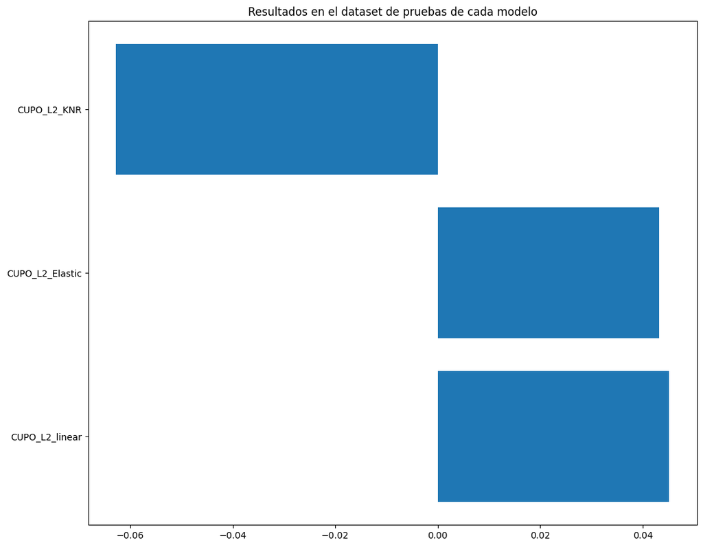

```python
plt.figure(figsize = (12,10)) # tamaño de la figura
plt.barh(range(len(resultados_prueba)), list(resultados_prueba.values()),
        align='center', );
plt.title("Resultados en el dataset de pruebas de cada modelo")
plt.yticks(range(len(resultados_prueba)), list(resultados_prueba.keys()));
```

```python
models = []

# Alamcenando los modelos como una tupla (nombre, modelo)
models.append(('CUPO_L2_Linear',LinearRegression()))
models.append(('CUPO_L2_Elastic',ElasticNet(alpha=1,
                                            l1_ratio=0.5,
                                            max_iter= 100000,
                                            warm_start= True)))
models.append(('CUPO_L2_KNR',KNeighborsRegressor(n_neighbors=10)))
```

### EL CLASIFICADOR ELEGIDO ES CUPO_L2_LINEAR

Es el que tiene mejores resultados Prueba_R2 : 0.04517329077203258 Prueba_MSE : 499258418660.7424 Prueba_RMSE : 706582.2094142637

### CLASIFICACIÓN

#### Librerías

```python
from sklearn.model_selection import train_test_split
from sklearn.metrics import accuracy_score
from sklearn.metrics import precision_score
from sklearn.metrics import recall_score
from sklearn.metrics import f1_score

from sklearn.linear_model import LogisticRegression
from sklearn.discriminant_analysis import LinearDiscriminantAnalysis
from sklearn.discriminant_analysis import QuadraticDiscriminantAnalysis
from sklearn.linear_model import SGDClassifier
from sklearn.svm import LinearSVC
from sklearn.neighbors import RadiusNeighborsClassifier
from sklearn.naive_bayes import GaussianNB
from sklearn.tree import DecisionTreeClassifier
```

```python
['Antiguedad','internauta', 'Region', 'Monoproducto','Ctacte', 'Edad','TC','Cuentas', 'Debito','CambioPin']
```

```
['Antiguedad',
 'internauta',
 'Region',
 'Monoproducto',
 'Ctacte',
 'Edad',
 'TC',
 'Cuentas',
 'Debito',
 'CambioPin']
```

```python
def classification(y_test, y_pred):

    acc = accuracy_score(y_test, y_pred, normalize=True)
    f1_ac = f1_score(y_test, y_pred)

    prec = precision_score(y_test, y_pred)
    recall = recall_score(y_test, y_pred)

    return {'accuracy': acc,
            'precision': prec,
            'recall':recall,
            'F1':f1_ac}
```

```python
df_clasificación = df[['Antiguedad', 'Internauta', 'Region', 'Monoproducto',
                       'Ctacte', 'Edad', 'TC', 'Cuentas', 'Debito', 'CambioPin', ]]

X = df_clasificación.drop(['Internauta'], axis=1)

Y = df['Internauta']

x_train, x_test, y_train, y_test = train_test_split(
    X, Y, test_size=0.2)
```

```python
lr = LogisticRegression(solver='liblinear')
sgdc = SGDClassifier(max_iter=1001)
dt = DecisionTreeClassifier(max_depth=5)
```

### Clasificaciones

```python
# entrenar los modelos
lr.fit(x_train, y_train)
sgdc.fit(x_train, y_train)
dt.fit(x_train, y_train)

modelos = [lr, sgdc, dt]
```

### Datos Logísticos

```python
# mostrar los resultados de matriz de confusión
# importar la librerias
from sklearn.metrics import confusion_matrix

for model in modelos:
    print(model)
    print()
    y_pred = model.predict(x_test)
    cm = confusion_matrix(y_test, y_pred)
    print(cm)
    print(f'\nSuma Diagonal: {cm.trace()} de {cm.sum()}')
    print()
```

```
LogisticRegression(solver='liblinear')

[[1297 1901]
 [ 609 6418]]

Suma Diagonal: 7715 de 10225

SGDClassifier(max_iter=1001)

[[ 755 2443]
 [ 493 6534]]

Suma Diagonal: 7289 de 10225

DecisionTreeClassifier(max_depth=5)

[[1336 1862]
 [ 662 6365]]

Suma Diagonal: 7701 de 10225
```

### Accuracy, sensibilidad, precisión y F1

```python
## acurracy, precision, recall, f1-score del los modelos
from sklearn.metrics import accuracy_score, precision_score, recall_score, f1_score

for model in modelos:
    print(model)
    print()
    y_pred = model.predict(x_test)
    print(
        f'El accuracy del modelo es {accuracy_score(y_test, y_pred):.2f}')
    print(
        f'El precision del modelo es {precision_score(y_test, y_pred):.2f}')
    print(
        f'El recall del modelo es {recall_score(y_test, y_pred):.2f}')
    print(
        f'El f1-score del modelo es {f1_score(y_test, y_pred):.2f}\n')
    print()
```

```
LogisticRegression(solver='liblinear')

El accuracy del modelo es 0.75
El precision del modelo es 0.77
El recall del modelo es 0.91
El f1-score del modelo es 0.84


SGDClassifier(max_iter=1001)

El accuracy del modelo es 0.71
El precision del modelo es 0.73
El recall del modelo es 0.93
El f1-score del modelo es 0.82


DecisionTreeClassifier(max_depth=5)

El accuracy del modelo es 0.75
El precision del modelo es 0.77
El recall del modelo es 0.91
El f1-score del modelo es 0.83
```

### Curva ROC

```
LogisticRegression(solver='liblinear')

El AUC del modelo es 0.66 - accuracy: 0.75 = Diferencia de -0.094
```

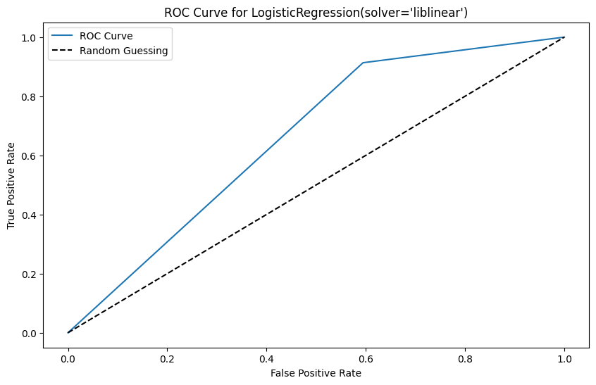

```
SGDClassifier(max_iter=1001)

El AUC del modelo es 0.58 - accuracy: 0.75 = Diferencia de -0.172
```

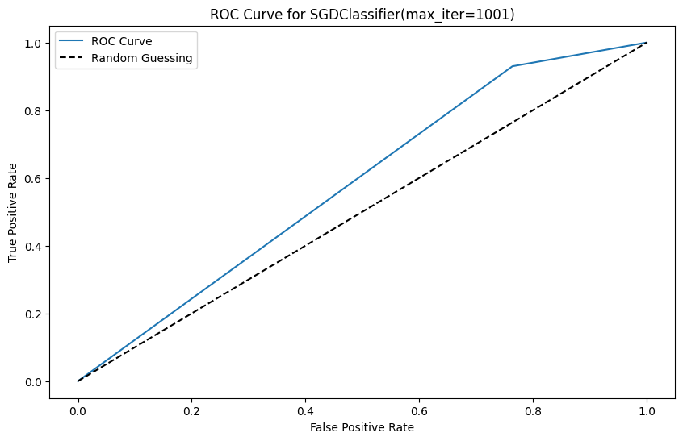

```
DecisionTreeClassifier(max_depth=5)

El AUC del modelo es 0.66 - accuracy: 0.71 = Diferencia de -0.051
```

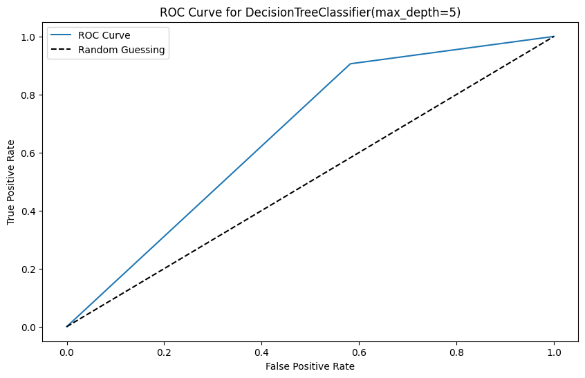

```python
### graficar la curva ROC para los modelos y calcular el AUC y comparar con el accuracy
from sklearn.metrics import roc_curve, roc_auc_score

for model in modelos:
    print(model)
    print()
    accuracy = accuracy_score(y_test, y_pred)
    y_pred = model.predict(x_test)
    fpr, tpr, thresholds = roc_curve(y_test, y_pred)
    print(
        f'El AUC del modelo es {roc_auc_score(y_test, y_pred):.2f} - accuracy: {accuracy:.2f} = Diferencia de {(roc_auc_score(y_test, y_pred) - accuracy):.3f} ')
    print()

    plt.figure(figsize=(10, 6))
    plt.plot(fpr, tpr, label='ROC Curve')
    plt.plot([0, 1], [0, 1], 'k--', label='Random Guessing')
    plt.xlabel('False Positive Rate')
    plt.ylabel('True Positive Rate')
    plt.title(f'ROC Curve for {model}')
    plt.legend()
    plt.show()
    print()
```

### Balanceo

Dado a que los datos no se encuentran desproporcionados no se decide realizar balanceo

### Mejores Características

```python
# importar librerias
from sklearn.metrics import classification_report

# entrenamiento random forest
from sklearn.ensemble import RandomForestClassifier

rf = RandomForestClassifier(n_estimators=100, max_depth=5)
rf.fit(x_train, y_train)


for score, name in zip(rf.feature_importances_, x_train.columns):
    print(f'La característica {name} tiene un score de {score:.2f}')
```

```
La característica Antiguedad tiene un score de 0.05
La característica Region tiene un score de 0.03
La característica Monoproducto tiene un score de 0.13
La característica Ctacte tiene un score de 0.22
La característica Edad tiene un score de 0.48
La característica TC tiene un score de 0.00
La característica Cuentas tiene un score de 0.00
La característica Debito tiene un score de 0.07
La característica CambioPin tiene un score de 0.01
```

# Nota 3

### Casos de Uso

1. Clasificación por Comportamiento Financiero:
- Cluster 1: Clientes que mantienen saldos pendientes significativos en sus tarjetas.
- Cluster 2: Clientes que realizan principalmente transacciones en efectivo.
- Cluster 3: Clientes que tienden a saldar sus deudas mensualmente.

Usaremos las columnas Renta Antiguedad Ctacte Consumo Hipotecario Debito Cuentas TC CUPO_L1 CUPO_L2 CUPO_MX

2. Clasificación por Antigüedad y Número de Cuentas:
- Cluster 1: Clientes con larga antigüedad y múltiples cuentas.
- Cluster 2: Clientes nuevos con una sola cuenta.
- Cluster 3: Clientes con antigüedad moderada y varias cuentas.

Usaremos las columnas Edad Renta Antiguedad Dualidad Monoproducto Ctacte Consumo Hipotecario Debito Cuentas

3. Clasificación por Comportamiento de Pago:
- Cluster 1: Clientes que tienden a pagar sus deudas a tiempo.
- Cluster 2: Clientes con historial de pagos inconsistentes.
- Cluster 3: Clientes con problemas recurrentes de pago.

Usaremos las columnas Edad Renta Consumo TC CUPO_L1 CUPO_L2 CUPO_MX

Usaremos la opción 3 porque nos parece más interesante

### Clusterización

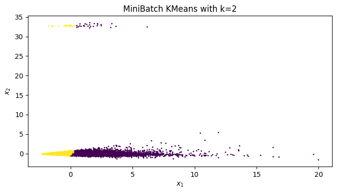

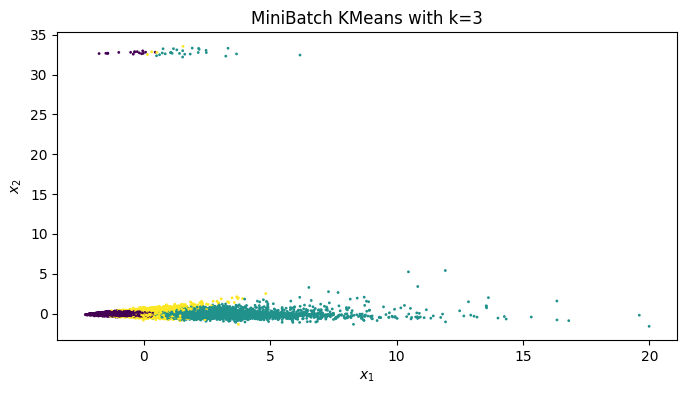

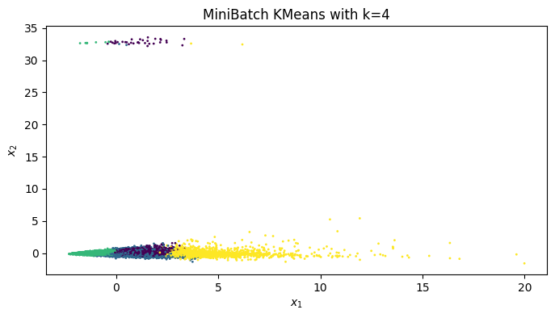

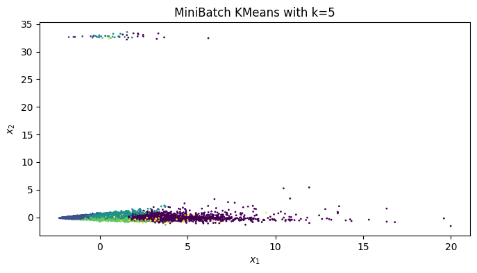

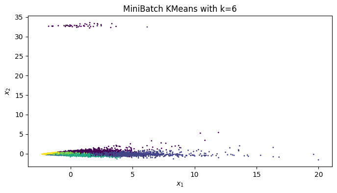

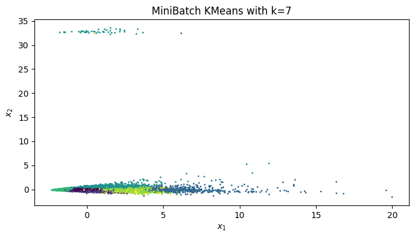

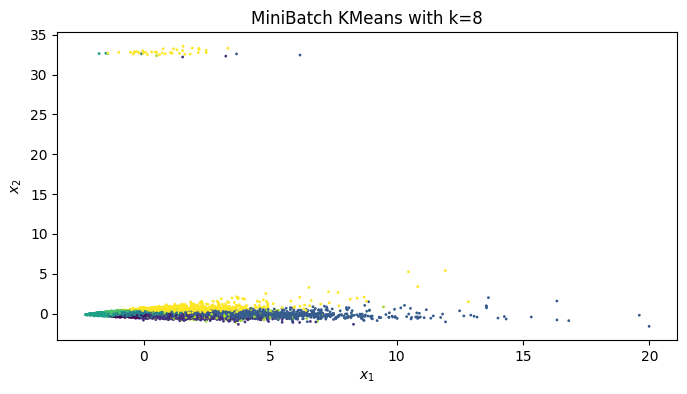

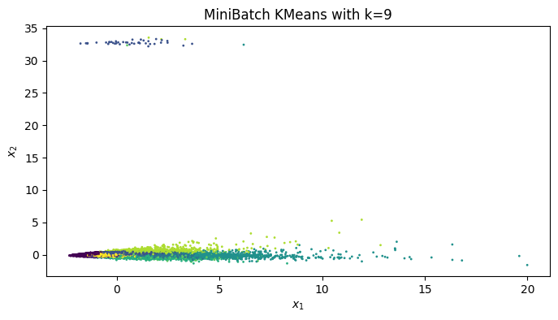

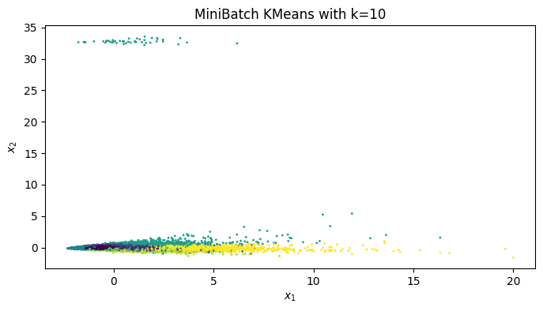

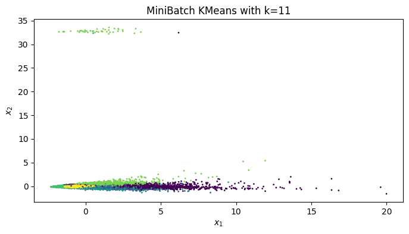

```python
from sklearn.cluster import MiniBatchKMeans
from sklearn.preprocessing import StandardScaler
from sklearn.metrics import silhouette_score
import matplotlib.pyplot as plt
from sklearn.decomposition import PCA

columnas_a_usar = ['Renta', 'Edad', 'Consumo', 'TC', 'CUPO_L1', 'CUPO_MX', 'CUPO_L2']
X = df[columnas_a_usar]

# Normalización de los datos
scaler = StandardScaler()
X_scaled = scaler.fit_transform(X)

# Reducción de Dimensionalidad para Visualización
# Usamos PCA para reducir a 2D ya que tenemos más de dos características
pca = PCA(n_components=2)
X_pca = pca.fit_transform(X_scaled)

# Rango de k's a probar
k_range = range(2, 12)
inertias = []
for k in k_range:
    mbkmeans = MiniBatchKMeans(n_clusters=k, random_state=42)
    mbkmeans.fit(X_scaled)
    labels = mbkmeans.labels_
    inertias.append(mbkmeans.inertia_)

    # Visualización
    plt.figure(figsize=(8, 4))
    plt.scatter(X_pca[:, 0], X_pca[:, 1], c=labels, s=1)  # Asumiendo 2D para visualización
    plt.title(f"MiniBatch KMeans with k={k}")
    plt.xlabel("$x_1$")
    plt.ylabel("$x_2$")
    plt.show()
```

### K-óptimo

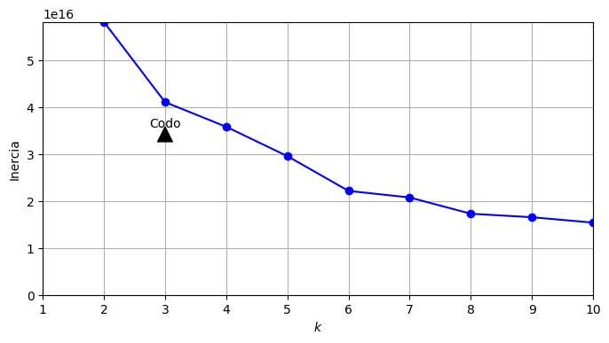

```python
# Asumiendo que X es tu conjunto de datos ya escalado
k_range = range(2, 12)
kmeans_per_k = [MiniBatchKMeans(n_clusters=k, random_state=42).fit(X) for k in k_range]
inertias = [model.inertia_ for model in kmeans_per_k]

plt.figure(figsize=(8, 4))
plt.plot(k_range, inertias, "bo-")
plt.xlabel("$k$")
plt.ylabel("Inercia")

# Encontrar el punto de codo y añadir anotación
k_elbow = 3  # Reemplaza esto con el valor de k que identificas como el punto de codo
plt.annotate('Codo', xy=(k_elbow, inertias[k_elbow-1]), xytext=(k_elbow, inertias[k_elbow-1] + 200),
             arrowprops=dict(facecolor='black', shrink=0.05), ha='center')

plt.axis([1, 10, 0, max(inertias) + 200])
plt.grid()
# save_fig("inertia_vs_k_plot")  # Comenta o elimina esta línea si no tienes definida la función 'save_fig'
plt.show()
```

Nuestra hipotesis dice que el codo esta en el 4

### Comprobación K-óptimo

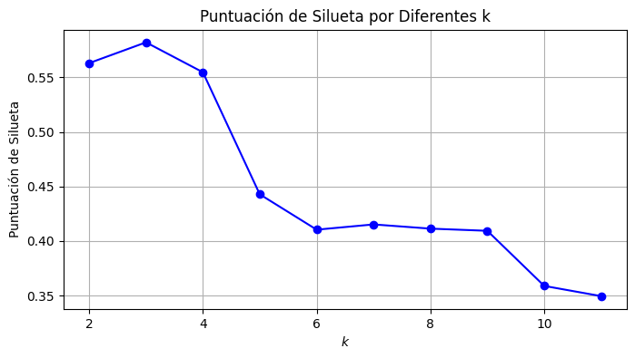

```python
from sklearn.metrics import silhouette_score
import matplotlib.pyplot as plt
from sklearn.cluster import MiniBatchKMeans

# Asumiendo que X es tu conjunto de datos ya escalado
k_range = range(2, 12)
silhouette_scores = []

for k in k_range:
    mbkmeans = MiniBatchKMeans(n_clusters=k, random_state=42)
    mbkmeans.fit(X)
    score = silhouette_score(X, mbkmeans.labels_)
    silhouette_scores.append(score)

# Gráfico de la puntuación de silueta
plt.figure(figsize=(8, 4))
plt.plot(k_range, silhouette_scores, "bo-")
plt.xlabel("$k$")
plt.ylabel("Puntuación de Silueta")
plt.title("Puntuación de Silueta por Diferentes k")
plt.grid()
plt.show()
```

Hemos visto que nuestra hipotesis era erronea y la mejor cantidad de cluster son 3

### Uso DBSCAN

```
Para min_samples=5 y eps=0.1 se obtienen 10 clusters
```

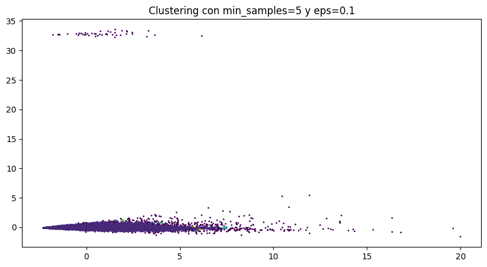

```
Para min_samples=5 y eps=0.2 se obtienen 7 clusters
```

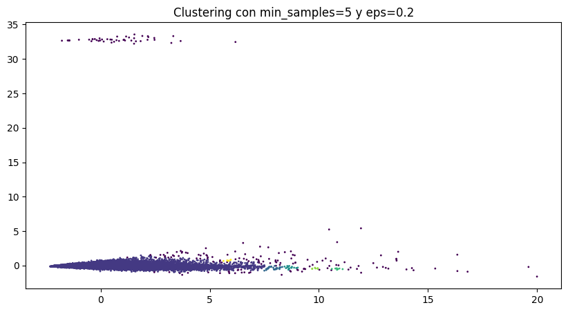

```
Para min_samples=5 y eps=0.3 se obtienen 9 clusters
```

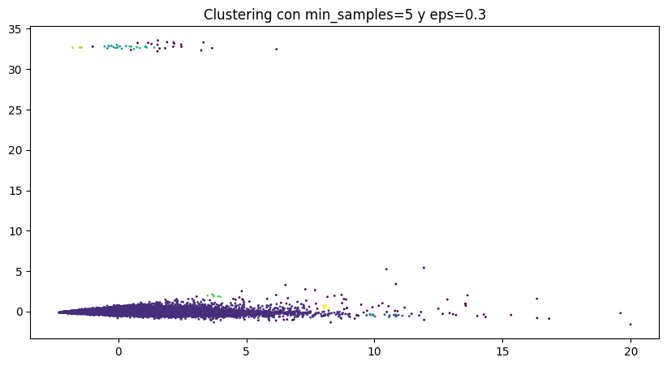

```
Para min_samples=5 y eps=0.4 se obtienen 7 clusters
```

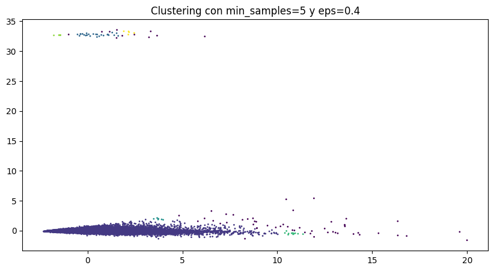

```
Para min_samples=5 y eps=0.5 se obtienen 3 clusters
```

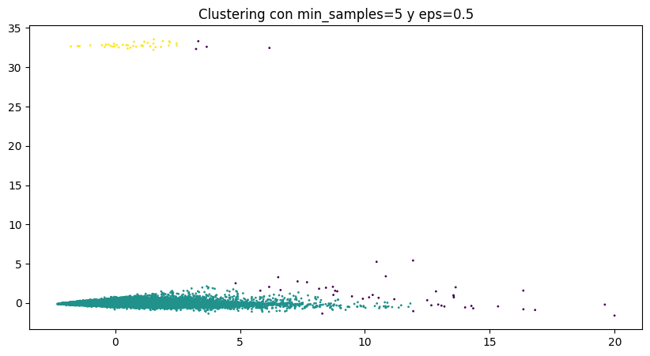

```
Para min_samples=10 y eps=0.1 se obtienen 4 clusters
```

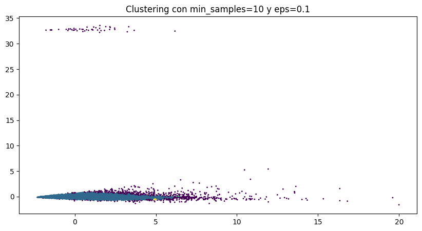

```
Para min_samples=10 y eps=0.2 se obtienen 3 clusters
```

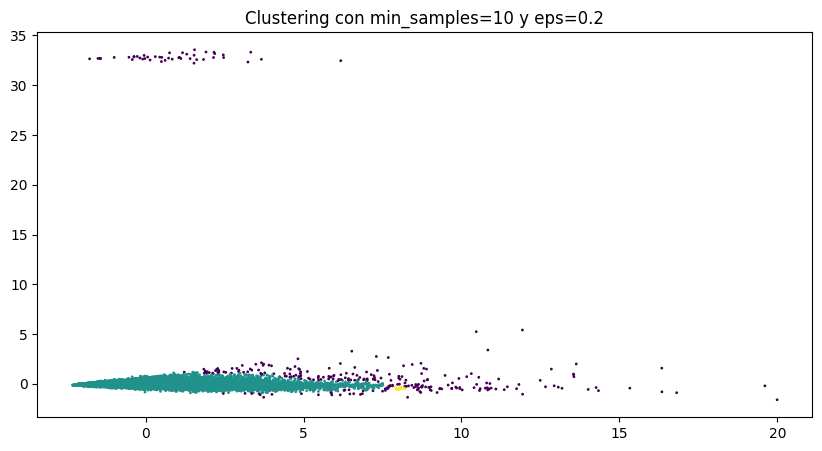

```
Para min_samples=10 y eps=0.3 se obtienen 2 clusters
```

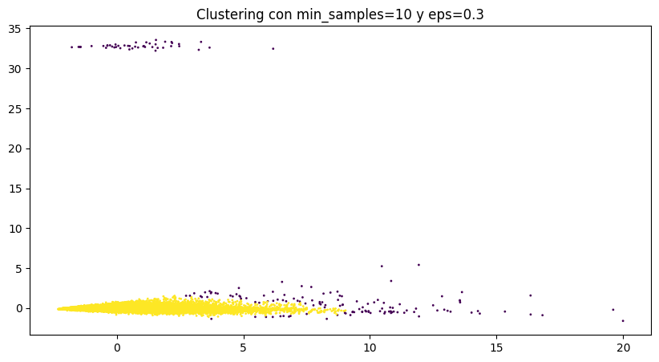

```
Para min_samples=10 y eps=0.4 se obtienen 3 clusters
```

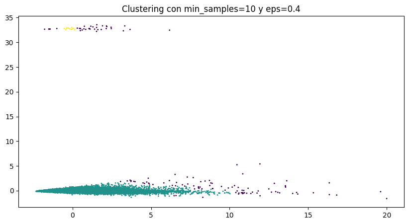

```
Para min_samples=10 y eps=0.5 se obtienen 4 clusters
```

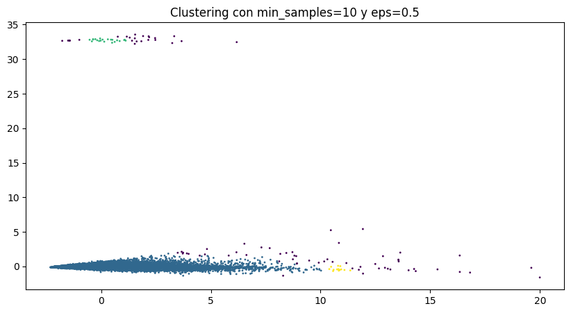

```
Para min_samples=20 y eps=0.1 se obtienen 5 clusters
```

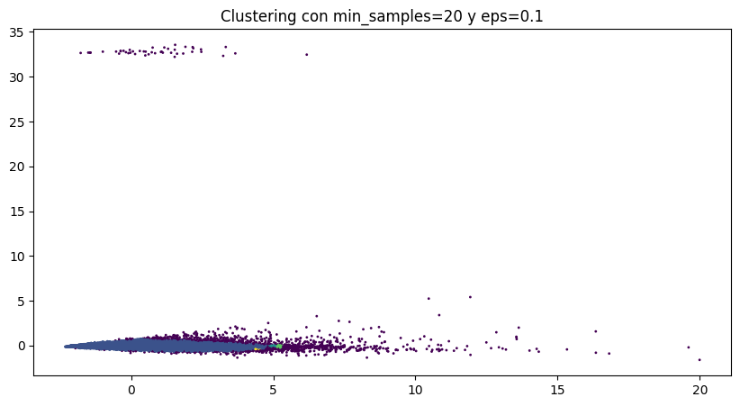

```
Para min_samples=20 y eps=0.2 se obtienen 2 clusters
```

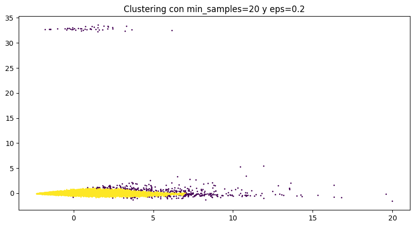

```
Para min_samples=20 y eps=0.3 se obtienen 2 clusters
```

[8 more figures not shown]

```python
from sklearn.cluster import DBSCAN

min_samples = [5, 10, 20, 50]
eps = [ 0.1, 0.2, 0.3, 0.4, 0.5]

for sample in min_samples:
    for e in eps:
        dbscan = DBSCAN(eps=e, min_samples=sample)
        dbscan.fit(X_pca)

        print(f'Para min_samples={sample} y eps={e} se obtienen {len(np.unique(dbscan.labels_))} clusters')
        plt.figure(figsize=(10, 5))
        plt.scatter(X_pca[:, 0], X_pca[:, 1], c=dbscan.labels_, s=1)
        plt.title(f'Clustering con min_samples={sample} y eps={e}')
        plt.show()
```

Revisando los cluster graficados notamos que la mejor opción es la Kmeans, puesto que los clustes realizados por dbscan realizan sus cluster de manera poco uniforme, no como Kmeans que realiza 3 cluster de manera casi vertical, asi que esa será nuestra decisión

### Asociaciones

Usando la tercera opción

3. Clasificación por Comportamiento de Pago:
- Cluster 1: Clientes que tienden a pagar sus deudas a tiempo.
- Cluster 2: Clientes con historial de pagos inconsistentes.
- Cluster 3: Clientes con problemas recurrentes de pago.

pondremos a prueba 3 usuarios para ver en que cluster quedará, pero primero necesitamos saber el rango de la información de los datos que se usaron para los cluster

```python
X.describe()
```

|  | Renta | Edad | Consumo | TC | CUPO_L1 | CUPO_MX | CUPO_L2 |
| --- | --- | --- | --- | --- | --- | --- | --- |
| count | 5.112400e+04 | 51124.000000 | 51124.000000 | 51124.000000 | 5.112400e+04 | 51124.000000 | 5.112400e+04 |
| mean | 6.299582e+05 | 38.702879 | 0.000900 | 1.732376 | 1.133187e+06 | 1400.352823 | 3.284847e+05 |
| std | 3.676182e+05 | 13.302573 | 0.029983 | 0.877470 | 1.076922e+06 | 1597.353436 | 7.577834e+05 |
| min | 1.000000e+00 | 9.000000 | 0.000000 | 1.000000 | 0.000000e+00 | 0.000000 | 0.000000e+00 |
| 25% | 4.025490e+05 | 28.000000 | 0.000000 | 1.000000 | 4.000000e+05 | 300.000000 | 1.000000e+03 |
| 50% | 5.539895e+05 | 35.000000 | 0.000000 | 2.000000 | 8.000000e+05 | 1000.000000 | 1.000000e+05 |
| 75% | 7.622517e+05 | 46.000000 | 0.000000 | 2.000000 | 1.527000e+06 | 1900.000000 | 2.400000e+05 |
| max | 1.308933e+07 | 104.000000 | 1.000000 | 12.000000 | 2.153400e+07 | 40000.000000 | 1.255000e+07 |

```python
usuario_1 = [402549, 15, 0, 1, 0, 0, 0]
usuario_2 = [553989, 30, 0, 2, 80000, 1000, 10000]
usuario_3 = [1308993, 55, 1, 12, 215340, 40000, 125500]

# se hace df de usuarios
df_usuario = pd.DataFrame([usuario_1, usuario_2, usuario_3], columns=columnas_a_usar)

# se hace la prediccion mbk
mbkmeans = MiniBatchKMeans(n_clusters=3, random_state=42)
mbkmeans.fit(df_usuario)


# Se imprime resultado

print(f'Los 3 usuarios pertenecen a los clusters {mbkmeans.labels_}')
```

```
Los 3 usuarios pertenecen a los clusters [1 1 0]
```

### Registros Anómalos

Se necesita revisar el 5% de anomalias, para eso usaremos GaussinaMixture

```python
from sklearn.mixture import GaussianMixture

gm = GaussianMixture(n_components=3, n_init=10, random_state=42)
gm.fit(X)
gm.predict(X)
```

```
array([0, 2, 2, ..., 2, 0, 0], dtype=int64)
```

Ahora se buscaran las anomalias

```python
densities = gm.score_samples(X)
density_threshold = np.percentile(densities, 5)
anomalies = X[densities < density_threshold]

anomalies.head(25)
```

|  | Renta | Edad | Consumo | TC | CUPO_L1 | CUPO_MX | CUPO_L2 |
| --- | --- | --- | --- | --- | --- | --- | --- |
| 10 | 847869.49 | 38 | 0 | 1 | 5000000 | 8300.0 | 1000.0 |
| 15 | 759228.80 | 46 | 0 | 2 | 800000 | 1200.0 | 5720000.0 |
| 34 | 2024451.00 | 44 | 0 | 1 | 3000000 | 2500.0 | 600000.0 |
| 114 | 4848389.00 | 47 | 0 | 2 | 2325000 | 1550.0 | 150000.0 |
| 117 | 1327963.00 | 49 | 0 | 5 | 1500000 | 2970.0 | 1250000.0 |
| 166 | 949894.00 | 47 | 0 | 2 | 6612000 | 6000.0 | 2.0 |
| 168 | 703912.42 | 43 | 0 | 1 | 2086000 | 6325.0 | 417300.0 |
| 175 | 912814.00 | 46 | 0 | 2 | 4207500 | 2000.0 | 2.0 |
| 180 | 837048.57 | 47 | 0 | 2 | 3326000 | 7890.0 | 1.0 |
| 197 | 1907435.00 | 48 | 0 | 2 | 400000 | 500.0 | 80000.0 |
| 219 | 976495.00 | 45 | 0 | 2 | 5200000 | 5200.0 | 1001.0 |
| 232 | 126115.00 | 47 | 0 | 4 | 1596000 | 1636.0 | 3800000.0 |
| 234 | 2377479.00 | 46 | 0 | 1 | 3000000 | 3000.0 | 1.0 |
| 239 | 2112646.00 | 49 | 0 | 1 | 1000000 | 1000.0 | 200000.0 |
| 258 | 1604670.00 | 33 | 0 | 1 | 650000 | 700.0 | 5590000.0 |
| 260 | 1104750.00 | 47 | 0 | 2 | 5396250 | 5500.0 | 301000.0 |
| 292 | 2003846.00 | 48 | 0 | 2 | 3500000 | 3550.0 | 301000.0 |
| 320 | 2885667.00 | 48 | 0 | 2 | 8825000 | 13681.0 | 3000001.0 |
| 339 | 1214443.00 | 44 | 0 | 2 | 1816700 | 1648.0 | 6481000.0 |
| 346 | 881443.15 | 67 | 0 | 1 | 3000800 | 7260.0 | 1.0 |
| 357 | 753803.41 | 49 | 1 | 1 | 500000 | 2500.0 | 100000.0 |
| 365 | 662353.00 | 50 | 0 | 1 | 1093500 | 700.0 | 5623154.0 |
| 373 | 2008223.00 | 48 | 0 | 3 | 1470002 | 2300.0 | 1000.0 |
| 398 | 896222.84 | 47 | 0 | 1 | 4600000 | 9000.0 | 1.0 |
| 463 | 1961843.00 | 38 | 0 | 2 | 3600000 | 6492.0 | 880000.0 |